# Spatial Regression Exercise

Jack Kauphusman

11/20/2019

# 1 Intro

In this exercise I will be attempting to do spatial regression analysis on Oklahoma trying to identify what is spatially correlated with child poverty.

So, lets learn about Oklahoma because I know nothing about it!!

[figure not shown]

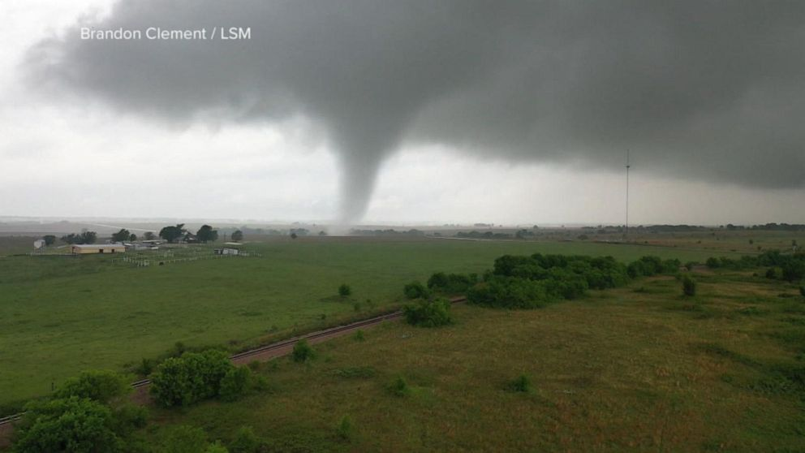

# 2 Regression Analysis

```r
packages<-c("cowplot", "dplyr", "geosphere", "ggplot2", "ggExtra", "mapproj","maps", "maptools", "readxl", "rgdal", "rgeos", "sf", "sp", "spatialreg", "spdep", "tidyr", "viridis")
sapply(packages, require, character.only=T)
```

```
   cowplot      dplyr  geosphere    ggplot2    ggExtra    mapproj       maps   maptools     readxl      rgdal      rgeos         sf
      TRUE       TRUE       TRUE       TRUE       TRUE       TRUE       TRUE       TRUE       TRUE       TRUE       TRUE       TRUE
        sp spatialreg      spdep      tidyr    viridis
      TRUE       TRUE       TRUE       TRUE       TRUE
```

```r
data <- read.csv('./data/childpov18_southfull.csv',
                   colClasses = c("character", "character", "character",
                                  "numeric", "numeric", "numeric", "numeric",
                                  "numeric", "numeric", "numeric", "numeric",
                                  "numeric", "numeric", "numeric", "numeric",
                                  "numeric", "numeric", "numeric", "numeric",
                                  "numeric", "numeric", "numeric", "numeric",
                                  "numeric", "numeric", "numeric", "numeric",
                                  "numeric", "numeric", "numeric", "numeric",
                                  "numeric", "numeric", "numeric", "numeric"))

names(data)[names(data)=="X2016.child.poverty"] <- "child.pov.2016"
ok_pov <- data %>% subset(State == "OK")
```

## 2.1 Ordinary Least Squares

```r
equation <- child.pov.2016 ~ rural + urban + lnmanufacturing + lnag +
            lnretail + lnhealthss + lnconstruction + lnlesshs +
            lnunemployment + lnsinglemom + lnblack + lnhispanic +
            lnuninsured + lnincome_ratio + lnteenbirth + lnunmarried

options(scipen = 5)

ols <- lm(equation, data=ok_pov)
summary(ols)
```

```
Call:
lm(formula = equation, data = ok_pov)

Residuals:
    Min      1Q  Median      3Q     Max
-6.8921 -2.1439 -0.2192  1.8061  8.9392

Coefficients:
                 Estimate Std. Error t value Pr(>|t|)
(Intercept)     -44.43250   23.43205  -1.896  0.06275 .
rural             0.06508    1.59996   0.041  0.96769
urban            -1.57818    1.42922  -1.104  0.27390
lnmanufacturing  -1.46656    1.59416  -0.920  0.36128
lnag             -0.82352    1.27584  -0.645  0.52108
lnretail         -3.83327    3.50054  -1.095  0.27787
lnhealthss        1.14885    4.57403   0.251  0.80254
lnconstruction   -2.30946    3.10651  -0.743  0.46013
lnlesshs          0.89121    3.89094   0.229  0.81961
lnunemployment   10.61587    3.07216   3.456  0.00101 **
lnsinglemom       1.27034    2.68889   0.472  0.63833
lnblack          -0.09205    0.59802  -0.154  0.87819
lnhispanic       -0.50339    1.09212  -0.461  0.64652
lnuninsured      18.75564    7.45486   2.516  0.01457 *
lnincome_ratio    7.74313    5.95469   1.300  0.19846
lnteenbirth      -2.42881    1.67827  -1.447  0.15304
lnunmarried       0.34424    0.62957   0.547  0.58655
---
Signif. codes:  0 ‘***’ 0.001 ‘**’ 0.01 ‘*’ 0.05 ‘.’ 0.1 ‘ ’ 1

Residual standard error: 3.978 on 60 degrees of freedom
Multiple R-squared:  0.7311,    Adjusted R-squared:  0.6594
F-statistic:  10.2 on 16 and 60 DF,  p-value: 9.631e-12
```

Soooo, unemployment and uninsured are correlated with child poverty. But, lets try some….

# 3 Spatial Regression Analysis

```r
#Obtain FIPS Codes by county
fips <- county.fips

#Create county polygons
oklahoma <- map(database = "county", regions = "oklahoma", fill=T, plot=F)
IDs <- sub("^oklahoma,","",oklahoma$names)

#Add FIPS codes to the county polygons
fips.codes <- separate(data = fips, col = polyname, into = c("state", "county"), sep = ",")
ok_fips <- subset(fips.codes, state=="oklahoma", select=fips)
names <- fips.codes$county
ok_IDs <- unique(ok_fips$fips)

#Create spatial polygons
ok_sp = map2SpatialPolygons(oklahoma,ok_fips$fips,CRS("+proj=longlat"))
names(ok_sp@polygons) <- ok_IDs

#Create neighbor weights using the queens case
neighb.data <- poly2nb(ok_sp, queen=T)
names(neighb.data) <- names(ok_sp@polygons)

#Create list of neighbors
cont.neighb <- nb2listw(neighb.data,style="W", zero.policy = TRUE)
```

## 3.1 Moran’s Correlation and LaGrange Multiplier Tests

```r
lm.morantest(ols, cont.neighb)
```

```
    Global Moran I for regression residuals

data:
model: lm(formula = equation, data = ok_pov)
weights: cont.neighb

Moran I statistic standard deviate = 1.9824, p-value = 0.02372
alternative hypothesis: greater
sample estimates:
Observed Moran I      Expectation         Variance
      0.08677856      -0.04401049       0.00435266
```

The Moran’s Correlation Test identified, based on the p-value, that we should use a spatial model.

```r
lm.LMtests(ols, cont.neighb, test="all")
```

```
    Lagrange multiplier diagnostics for spatial dependence

data:
model: lm(formula = equation, data = ok_pov)
weights: cont.neighb

LMerr = 1.3831, df = 1, p-value = 0.2396


    Lagrange multiplier diagnostics for spatial dependence

data:
model: lm(formula = equation, data = ok_pov)
weights: cont.neighb

LMlag = 1.5889, df = 1, p-value = 0.2075


    Lagrange multiplier diagnostics for spatial dependence

data:
model: lm(formula = equation, data = ok_pov)
weights: cont.neighb

RLMerr = 0.19259, df = 1, p-value = 0.6608


    Lagrange multiplier diagnostics for spatial dependence

data:
model: lm(formula = equation, data = ok_pov)
weights: cont.neighb

RLMlag = 0.39838, df = 1, p-value = 0.5279


    Lagrange multiplier diagnostics for spatial dependence

data:
model: lm(formula = equation, data = ok_pov)
weights: cont.neighb

SARMA = 1.7815, df = 2, p-value = 0.4104
```

However, none of the spatial models are significant, soooo I’ll just decide to keep going through the first three model types

**Spatially lagged X Model**, **Spatial Lag Model**, & **Spatial Error Model**.

### 3.1.1 Spatially Lagged X Model

The SLX model accounts for the average value of neighboring X values within our model. Essentially this is a one-way interaction where potentially our neighbors have an impact on us, but that is the limit of the interactions (Gentry).

```r
SLX.model <- lmSLX(equation, data=ok_pov, cont.neighb)
summary(SLX.model)
```

```
Call:
lm(formula = formula(paste("y ~ ", paste(colnames(x)[-1], collapse = "+"))),
    data = as.data.frame(x), weights = weights)

Residuals:
   Min     1Q Median     3Q    Max
-6.090 -2.090 -0.431  2.006  7.099

Coefficients:
                     Estimate Std. Error t value Pr(>|t|)
(Intercept)         -52.57134   78.06767  -0.673  0.50421
rural                 0.97935    1.99250   0.492  0.62550
urban                -2.88093    1.69776  -1.697  0.09678 .
lnmanufacturing      -1.17794    1.77376  -0.664  0.51010
lnag                 -1.43293    1.45793  -0.983  0.33105
lnretail             -5.94167    3.83343  -1.550  0.12831
lnhealthss           -1.63543    5.30086  -0.309  0.75914
lnconstruction       -2.36760    3.64540  -0.649  0.51941
lnlesshs             -0.37000    4.93409  -0.075  0.94056
lnunemployment       10.52455    3.49094   3.015  0.00426 **
lnsinglemom           1.99621    3.16555   0.631  0.53156
lnblack               0.43075    0.73234   0.588  0.55941
lnhispanic           -1.31270    1.84572  -0.711  0.48070
lnuninsured          22.34831   10.30291   2.169  0.03552 *
lnincome_ratio        3.82442    7.48059   0.511  0.61174
lnteenbirth          -4.23351    2.01836  -2.097  0.04173 *
lnunmarried           0.07924    0.94434   0.084  0.93350
lag.rural           -13.25508    5.09712  -2.601  0.01263 *
lag.urban             1.81524    4.67595   0.388  0.69973
lag.lnmanufacturing  -2.97648    4.27695  -0.696  0.49013
lag.lnag              1.69721    3.33556   0.509  0.61342
lag.lnretail        -15.80984   10.34910  -1.528  0.13376
lag.lnhealthss        5.65047   18.57720   0.304  0.76244
lag.lnconstruction    5.10610   10.25040   0.498  0.62087
lag.lnlesshs        -10.52090   11.82822  -0.889  0.37859
lag.lnunemployment   -5.69200    7.35095  -0.774  0.44288
lag.lnsinglemom       2.51737    9.02415   0.279  0.78158
lag.lnblack          -0.59185    1.80910  -0.327  0.74511
lag.lnhispanic        0.55104    3.35242   0.164  0.87019
lag.lnuninsured      33.54103   22.79001   1.472  0.14821
lag.lnincome_ratio    1.63605   22.46760   0.073  0.94228
lag.lnteenbirth      -6.97307    6.55200  -1.064  0.29301
lag.lnunmarried      -0.64809    2.55640  -0.254  0.80105
---
Signif. codes:  0 ‘***’ 0.001 ‘**’ 0.01 ‘*’ 0.05 ‘.’ 0.1 ‘ ’ 1

Residual standard error: 3.951 on 44 degrees of freedom
Multiple R-squared:  0.8055,    Adjusted R-squared:  0.6641
F-statistic: 5.695 on 32 and 44 DF,  p-value: 0.00000009785
```

```r
summary(impacts(SLX.model, cont.neighb), zstats = TRUE)[["pzmat"]]
```

```
                     Direct    Indirect      Total
rural           0.623059009 0.009308737 0.02028339
urban           0.089715590 0.697862656 0.82530433
lnmanufacturing 0.506631073 0.486468977 0.37826766
lnag            0.325678690 0.610876427 0.93724885
lnretail        0.121150234 0.126598578 0.06349869
lnhealthss      0.757684998 0.761004816 0.83722586
lnconstruction  0.516030807 0.618387803 0.81798209
lnlesshs        0.940223334 0.373748095 0.43995883
lnunemployment  0.002571297 0.438740072 0.56541299
lnsinglemom     0.528300443 0.780276485 0.67275413
lnblack         0.556404449 0.743553760 0.93540723
lnhispanic      0.476950793 0.869440243 0.83707477
lnuninsured     0.030073021 0.141090379 0.04739368
lnincome_ratio  0.609179309 0.941950781 0.82934286
lnteenbirth     0.035949515 0.287207709 0.13111248
lnunmarried     0.933124297 0.799869090 0.85337500
```

A few other variables are now being shown as significant, such as teen birth in addition to unemployment and uninsured which was ID in the OLS. Also, the lagged rural variable is now significant suggesting neighbor interaction.

### 3.1.2 Spatial Lag Model

The Spatial Lag Model is a global model where the dependent variable among our neighbors influences our dependent variable. Therefore there is a feedback loop that occurs where affects on our neighbor(s) y affects our y and our neighbor(s) y variable.

```r
sp.lag.model <- spatialreg::lagsarlm(equation, data=ok_pov, cont.neighb)
summary(sp.lag.model, Nagelkerke = TRUE)
```

```
Call:spatialreg::lagsarlm(formula = equation, data = ok_pov, listw = cont.neighb)

Residuals:
     Min       1Q   Median       3Q      Max
-6.65435 -2.44139 -0.38705  1.80317  9.10724

Type: lag
Coefficients: (asymptotic standard errors)
                  Estimate Std. Error z value  Pr(>|z|)
(Intercept)     -42.618177  20.504987 -2.0784 0.0376698
rural             0.315232   1.392681  0.2263 0.8209301
urban            -1.523404   1.247448 -1.2212 0.2220041
lnmanufacturing  -1.100663   1.395272 -0.7889 0.4301985
lnag             -0.569424   1.119915 -0.5085 0.6111358
lnretail         -3.799036   3.057820 -1.2424 0.2140890
lnhealthss        0.785666   3.987753  0.1970 0.8438122
lnconstruction   -2.264591   2.703518 -0.8376 0.4022295
lnlesshs          0.088735   3.428144  0.0259 0.9793497
lnunemployment   10.002503   2.715180  3.6839 0.0002297
lnsinglemom       1.229320   2.343789  0.5245 0.5999301
lnblack          -0.074513   0.520445 -0.1432 0.8861542
lnhispanic       -0.149156   0.997441 -0.1495 0.8811290
lnuninsured      16.947773   6.597206  2.5689 0.0102013
lnincome_ratio    8.702153   5.233581  1.6628 0.0963619
lnteenbirth      -2.222535   1.465959 -1.5161 0.1294949
lnunmarried       0.330580   0.548003  0.6032 0.5463460

Rho: 0.16344, LR test value: 1.7583, p-value: 0.18483
Asymptotic standard error: 0.11342
    z-value: 1.4411, p-value: 0.14955
Wald statistic: 2.0768, p-value: 0.14955

Log likelihood: -205.0918 for lag model
ML residual variance (sigma squared): 11.984, (sigma: 3.4618)
Nagelkerke pseudo-R-squared: 0.73721
Number of observations: 77
Number of parameters estimated: 19
AIC: 448.18, (AIC for lm: 447.94)
LM test for residual autocorrelation
test value: 0.84506, p-value: 0.35795
```

```r
#Where Rho is the spatially lagged y multiplier
```

We see that the p-value (0.185) for the SLM was not significant.

### 3.1.3 Spatial Error Model

The Spatial Error model does not include lagged dependent or independent variables, but instead includes a function of our unexplained error and that of our neighbors (gentry).

```r
sp.err.model <- spatialreg::errorsarlm(equation, data=ok_pov, cont.neighb)
summary(sp.err.model, Nagelkerke = TRUE)
```

```
Call:spatialreg::errorsarlm(formula = equation, data = ok_pov, listw = cont.neighb)

Residuals:
     Min       1Q   Median       3Q      Max
-7.34620 -2.53402 -0.31347  1.72180  8.86477

Type: error
Coefficients: (asymptotic standard errors)
                  Estimate Std. Error z value   Pr(>|z|)
(Intercept)     -44.568190  20.622946 -2.1611   0.030688
rural             1.410751   1.406297  1.0032   0.315780
urban            -2.077923   1.272163 -1.6334   0.102389
lnmanufacturing  -0.716367   1.380748 -0.5188   0.603883
lnag             -0.650091   1.134962 -0.5728   0.566789
lnretail         -2.175515   2.929257 -0.7427   0.457672
lnhealthss        0.819687   3.977260  0.2061   0.836718
lnconstruction   -2.257715   2.580375 -0.8750   0.381598
lnlesshs          0.676052   3.234213  0.2090   0.834424
lnunemployment   10.884878   2.622262  4.1509 0.00003311
lnsinglemom       1.917043   2.201080  0.8710   0.383778
lnblack           0.031774   0.520337  0.0611   0.951309
lnhispanic       -0.897425   0.995939 -0.9011   0.367544
lnuninsured      17.198695   6.046294  2.8445   0.004448
lnincome_ratio    6.731593   5.035253  1.3369   0.181258
lnteenbirth      -2.164901   1.434410 -1.5093   0.131232
lnunmarried       0.224075   0.517034  0.4334   0.664735

Lambda: 0.38187, LR test value: 2.8909, p-value: 0.089083
Asymptotic standard error: 0.14282
    z-value: 2.6738, p-value: 0.0074987
Wald statistic: 7.1495, p-value: 0.0074987

Log likelihood: -204.5255 for error model
ML residual variance (sigma squared): 11.49, (sigma: 3.3897)
Nagelkerke pseudo-R-squared: 0.74104
Number of observations: 77
Number of parameters estimated: 19
AIC: 447.05, (AIC for lm: 447.94)
```

```r
#Where Lambda is the error multiplier
```

Unemployment is strongly correlated, however again the overal model is not significant, so I willl not continue with the following tests

# 4 Best Model Decision

**Soo,**

The best fit Model Table.

| OLS | Model | SLX | Model | Lag | Model | Err | Model |
| --- | --- | --- | --- | --- | --- | --- | --- |
| *Adj-R<sup>2</sup>* | *p-value* | *Adj-R<sup>2</sup>* | *p-value* | *R<sup>2</sup>* | *p-value* | *R<sup>2</sup>* | *p-value* |
| 0.66 | **<0.01** | 0.66 | **<0.01** | 0.74 | 0.18 | 0.74 | 0.09 |

I am going to run with the **SLX Model**!

# 5 Spatial Regression; Set-up for Map

## 5.1 Creating a list of K-neighbors

```r
all.xy <- centroid(ok_sp)
rownames(all.xy) <- ok_IDs
colnames(all.xy) <- cbind("x","y")
```

```r
#Create neighbors
all.dist.k1 <- knn2nb(knearneigh(all.xy, k=1, longlat = TRUE))
all.dist.k3 <- knn2nb(knearneigh(all.xy, k=3, longlat = TRUE))
all.dist.k5 <- knn2nb(knearneigh(all.xy, k=5, longlat = TRUE))

#Determine max k distance value to neighbor
all.max.k1 <- max(unlist(nbdists(all.dist.k1, all.xy, longlat=TRUE)))
all.max.k3 <- max(unlist(nbdists(all.dist.k3, all.xy, longlat=TRUE)))
all.max.k5 <- max(unlist(nbdists(all.dist.k5, all.xy, longlat=TRUE)))

#Calculate neighbors based on distance
all.sp.dist.k1 <- dnearneigh(all.xy, d1=0, d2=1 * all.max.k1, longlat = TRUE)
all.sp.dist.k3 <- dnearneigh(all.xy, d1=0, d2=1 * all.max.k3, longlat = TRUE)
all.sp.dist.k5 <- dnearneigh(all.xy, d1=0, d2=1 * all.max.k5, longlat = TRUE)

#Create neighbor list
all.dist.neighb.k1 <- nb2listw(all.sp.dist.k1,style="W", zero.policy = TRUE)
all.dist.neighb.k3 <- nb2listw(all.sp.dist.k3,style="W", zero.policy = TRUE)
all.dist.neighb.k5 <- nb2listw(all.sp.dist.k5,style="W", zero.policy = TRUE)
```

## 5.2 Distance SLX Model

To calculate a distance SLX model for each k-distance value we will use the following:

```r
all.dist.slx.k1 <- lmSLX(equation, data=ok_pov, listw = all.dist.neighb.k1)
all.dist.slx.k3 <- lmSLX(equation, data=ok_pov, listw = all.dist.neighb.k3)
all.dist.slx.k5 <- lmSLX(equation, data=ok_pov, listw = all.dist.neighb.k5)
```

# 6 Mapping

Now, I will create a Spatial Regression map using the Spatial lag X Model with k3 distance comparing child poverty with unemployment!!

```r
dist.slx.data <- summary(all.dist.slx.k3, correlation=TRUE)

dist.slx.output <- cbind.data.frame(ok_pov$FIPS,
                               dist.slx.data$residual,
                               ok_pov$child.pov.2016,
                               ok_pov$rural,
                               ok_pov$urban,
                               ok_pov$lnunemployment,
                               stringsAsFactors = FALSE)

#Renaming columns
colnames(dist.slx.output) <- c("fips","resid","childpov",
                               "rural","urban","ln_unemployment")
```

```r
#Create quantiles
quantiles_sm <- dist.slx.output %>%
  pull(ln_unemployment) %>%
  quantile(probs = seq(0, 1, length.out = 4), na.rm = TRUE)

quantiles_pov <- dist.slx.output %>%
  pull(childpov) %>%
  quantile(probs = seq(0, 1, length.out = 4), na.rm = TRUE)

#Create ranks
sm_rank <- cut(dist.slx.output$ln_unemployment,
               breaks= quantiles_sm,
               labels=c("1", "2", "3"),
               na.rm = TRUE,
               include.lowest = TRUE)

pov_rank <- cut(dist.slx.output$childpov,
                breaks= quantiles_pov,
                labels=c("1", "2", "3"),
                na.rm = TRUE,
                include.lowest = TRUE)

#Join ranks and combined column to dataset
dist.slx.output$unemployment_score <- as.numeric(sm_rank)
dist.slx.output$pov_score <- as.numeric(pov_rank)
dist.slx.output$unemployment_pov <- paste(as.numeric(dist.slx.output$pov_score),
                         "-",
                         as.numeric(dist.slx.output$unemployment_score))
```

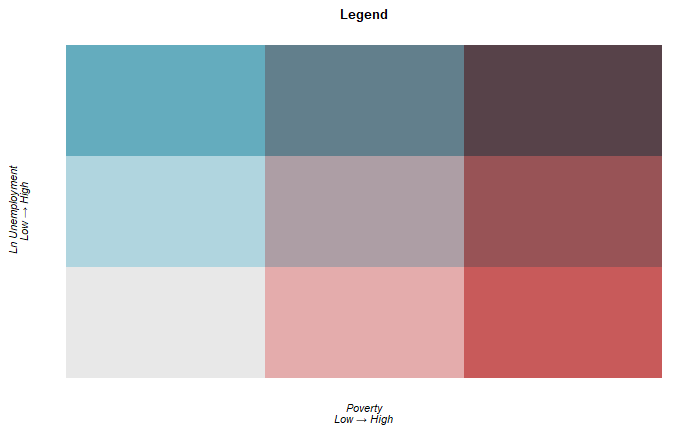

```r
legend_colors <- tibble(
  x = c(3,2,1,3,2,1,3,2,1),
  y = c(3,3,3,2,2,2,1,1,1),
  z = c("#574249", "#627f8c", "#64acbe", "#985356", "#ad9ea5", "#b0d5df", "#c85a5a", "#e4acac", "#e8e8e8"))

xlabel <- "Poverty,Low \u2192 High"
xlabel <- gsub(",", "\n", xlabel)
ylabel <- " Ln Unemployment,Low \u2192 High"
ylabel <- gsub(",", "\n", ylabel)

legend <- ggplot(legend_colors, aes(x,y)) +
  geom_tile(aes(fill=z)) +
  theme_minimal() + theme(legend.position = "none") +
  theme(panel.grid.major = element_blank(), panel.grid.minor = element_blank()) +
  theme(axis.text.x=element_blank(),
        axis.ticks.x=element_blank(),
        axis.text.y=element_blank(),
        axis.ticks.y=element_blank()) +
  labs(x = xlabel, y = ylabel) +
  scale_fill_identity() +
  ggtitle("Legend") +
  theme(axis.title.y = element_text(face = "italic", hjust = 0.5, size = 8)) +
  theme(axis.title.x = element_text(face = "italic", hjust = 0.5, size = 8)) +
  theme(plot.title = element_text(face="bold", hjust = 0.5, size = 10))

legend
```

```r
world <- map_data("world")
states <- map_data("state")
counties <- map_data("county")

counties$polyname <- paste(counties$region, counties$subregion, sep = ",")
counties <- counties %>% left_join(fips, by = c("polyname" = "polyname"))
counties$fips <- as.character(counties$fips)
counties <- counties %>% left_join(ok_pov, by = c("fips" = "FIPS"))

southern_states <- subset(states, region %in%
                            c("texas", "arkansas", "louisiana", "mississippi",
                              "alabama", "georgia", "florida", "north carolina",
                              "south carolina", "tennessee", "oklahoma",
                              "kentucky", "west virginia", "virginia",
                              "maryland", "delaware", "district of columbia"))

southern_counties <- subset(counties, region %in%
                              c("texas", "arkansas", "louisiana", "mississippi",
                                "alabama", "georgia", "florida", "north carolina",
                                "south carolina", "tennessee", "oklahoma",
                                "kentucky", "west virginia", "virginia",
                                "maryland", "delaware", "district of columbia"))

oklahoma_counties <- subset(southern_counties, region == "oklahoma")
```

```r
#Attach the data via the FIPS column and fortify the polygon
ok_poly <- oklahoma_counties %>%
  left_join(dist.slx.output, by = c("fips" = "fips")) %>%
  fortify

#Add custom color scheme based on ranks
bivariate_color_scale <- tibble(
  "3 - 3" = "#574249",
  "2 - 3" = "#627f8c",
  "1 - 3" = "#64acbe",
  "3 - 2" = "#985356",
  "2 - 2" = "#ad9ea5",
  "1 - 2" = "#b0d5df",
  "3 - 1" = "#c85a5a",
  "2 - 1" = "#e4acac",
  "1 - 1" = "#e8e8e8") %>%
  gather("group", "fill")

ok_poly <- ok_poly %>%
  left_join(bivariate_color_scale, by = c("unemployment_pov" = "group"))
```

```r
unemployment_pov_map <- ggplot() +
  geom_polygon(data = world, aes(x=long,y=lat, group=group), fill = "gray95", color = "white") +
  geom_polygon(data = states, aes(x=long,y=lat, group=group), fill = "gray", color = "white") +
  geom_polygon(data = ok_poly, aes(x=long, y=lat, group=group, fill = fill)) +
  geom_polygon(data = southern_states, aes(x=long,y=lat, group=group), fill = NA, color = "white") +
  geom_polygon(data = oklahoma_counties, aes(x=long,y=lat, group=group), fill = NA, color = "black", size = 0.05) +
  coord_map("conic", lat0 = 30, xlim=c(-105,-93), ylim=c(32.5,37)) +
  scale_fill_identity() +
  theme_grey() + theme(legend.position="bottom") + theme(legend.title.align=0.5) +
  theme(panel.background = element_rect(fill = 'deepskyblue'),
        panel.grid.major = element_line(colour = NA)) +
  labs(x = "Longitude", y = "Latitude", fill = "Child Poverty",
       title = "Bivariate Map of Child Poverty and Unemployment Rate (Ln)") +
  theme(plot.title = element_text(face = "bold", hjust = 0.5))
```

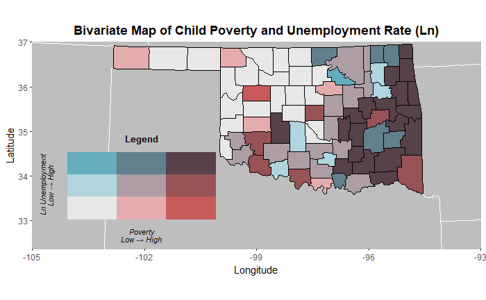

```r
final_map <- ggdraw() +
  draw_plot(unemployment_pov_map, x = 0, y = 0, width = 1, height = 1) +
  draw_plot(legend, x = 0.07, y = 0.17, width = 0.4, height = 0.4)

final_map
```

Look at that!!! Being by Arkansas is bad for buisness!